Q1: Implement REINFORCE with Gaussian policy model.

```python
import numpy as np
import lqg1d
import matplotlib.pyplot as plt
import utils
from scipy.stats import norm
import time
from math import *

class ConstantStep(object):
    def __init__(self, learning_rate):
        self.learning_rate = learning_rate

    def update(self, gt):
        return self.learning_rate * gt

class HarmonicStep(object):
    def __init__(self, learning_rate):
        self.learning_rate = learning_rate
    def update(self, k, gt):
        return (self.learning_rate/k) * gt

class Gaussian_policy:
    def __init__(self,std,theta):
        self.std = std
        self.theta = theta
    def gaussian1D(self,action,state):
        return norm.pdf(action,self.theta*state,self.std)
    def log_policy_gradient(self,action,state):
        return ((action-self.theta*state)/self.std**2)*state
    def draw_action(self,state):
        return np.random.normal(state*self.theta,self.std)
#####################################################
# Define the environment and the policy
#####################################################
env = lqg1d.LQG1D(initial_state_type='random')

policy = Gaussian_policy(0.5,-1)

#####################################################
# Experiments parameters
#####################################################
# We will collect N trajectories per iteration
N = 100
# Each trajectory will have at most T time steps
T = 100
# Number of policy parameters updates
n_itr = 100
# Set the discount factor for the problem
discount = 0.9
# Learning rate for the gradient update
learning_rate = 0.1
# Initial value for mean parameters theta
theta0 = -1

#####################################################
# define the update rule (stepper)
stepper = ConstantStep(learning_rate) # e.g., constant, adam or anything you want

# fill the following part of the code with
#  - REINFORCE estimate i.e. gradient estimate
def REINFORCE(paths,gamma=0.9):
    mean_estimation = 0
    for p in paths:
        df = 1
        sum_r = 0.
        for r in p["rewards"]:
            sum_r += df * r
            df *= gamma
        sum_grad = 0
        for a,s in zip(p["actions"],p["states"]):
            sum_grad += policy.log_policy_gradient(a,s)
        mean_estimation += sum_r*sum_grad
    return mean_estimation/len(paths)



#  - update of policy parameters using the steppers
def update_parameters(mean_estimation,theta,stepper):
    return theta + stepper.update(mean_estimation)
#  - average performance per iteration
def average_perfomance(paths,gamma=0.9):
    J = 0.
    for p in paths:
        df = 1
        sum_r = 0.
        for r in p["rewards"]:
            sum_r += df * r
            df *= gamma
        J += sum_r
    return J / len(paths)
#  - distance between optimal mean parameter and the one at it k
def distance_to_optimal(theta):
    return abs(-0.59-theta)
```

learning_rate = 0.1

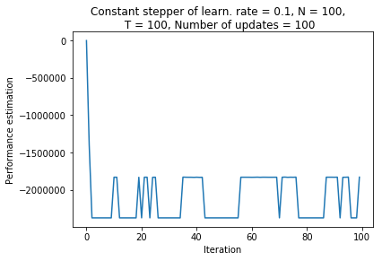

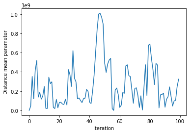

```python
mean_parameters = []
avg_return = []
distance_return = []
theta = theta0
mean_parameters.append(theta)
for _ in range(n_itr):
    policy = Gaussian_policy(0.5,theta)
    paths = utils.collect_episodes(env, policy=policy, horizon=T, n_episodes=N)
    mean_estimation = REINFORCE(paths,discount)
    theta = update_parameters(mean_estimation,theta,stepper)
    performance = average_perfomance(paths,discount)
    distance = distance_to_optimal(theta)
    mean_parameters.append(theta)
    avg_return.append(performance)
    distance_return.append(distance)

# plot the average return obtained by simulating the policy
# at each iteration of the algorithm (this is a rought estimate
# of the performance
plt.figure()
plt.plot(avg_return)
plt.suptitle('Constant stepper of learn. rate = '+str(learning_rate)+ ', N = ' +str(N)+',\n T = '+str(T)+", Number \
of updates = " + str(n_itr))
plt.xlabel('Iteration')
plt.ylabel('Performance estimation')
plt.show()

# plot the distance mean parameter
# of iteration k
plt.figure()
plt.plot(distance_return)
plt.xlabel('Iteration')
plt.ylabel('Distance mean parameter')
plt.show()
```

learning_rate = 0.01

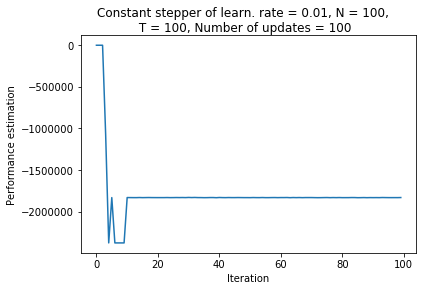

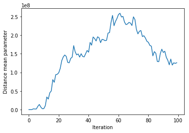

```python
learning_rate = 0.01
stepper = ConstantStep(learning_rate)
mean_parameters = []
avg_return = []
distance_return = []
theta = theta0
mean_parameters.append(theta)
for _ in range(n_itr):
    policy = Gaussian_policy(0.5,theta)
    paths = utils.collect_episodes(env, policy=policy, horizon=T, n_episodes=N)
    mean_estimation = REINFORCE(paths,discount)
    theta = update_parameters(mean_estimation,theta,stepper)
    performance = average_perfomance(paths,discount)
    distance = distance_to_optimal(theta)
    mean_parameters.append(theta)
    avg_return.append(performance)
    distance_return.append(distance)

# plot the average return obtained by simulating the policy
# at each iteration of the algorithm (this is a rought estimate
# of the performance
plt.figure()
plt.plot(avg_return)
plt.suptitle('Constant stepper of learn. rate = '+str(learning_rate)+ ', N = ' +str(N)+',\n T = '+str(T)+", Number \
of updates = " + str(n_itr))
plt.xlabel('Iteration')
plt.ylabel('Performance estimation')
plt.show()

# plot the distance mean parameter
# of iteration k
plt.figure()
plt.plot(distance_return)
plt.xlabel('Iteration')
plt.ylabel('Distance mean parameter')
plt.show()
```

learning_rate = 0.001

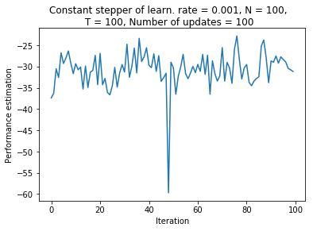

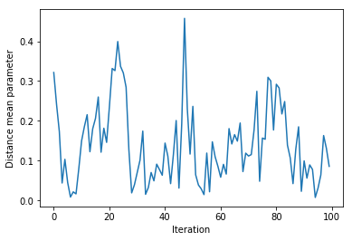

```python
learning_rate = 0.001
stepper = ConstantStep(learning_rate)
mean_parameters = []
avg_return = []
distance_return = []
theta = theta0
mean_parameters.append(theta)
for _ in range(n_itr):
    policy = Gaussian_policy(0.5,theta)
    paths = utils.collect_episodes(env, policy=policy, horizon=T, n_episodes=N)
    mean_estimation = REINFORCE(paths,discount)
    theta = update_parameters(mean_estimation,theta,stepper)
    performance = average_perfomance(paths,discount)
    distance = distance_to_optimal(theta)
    mean_parameters.append(theta)
    avg_return.append(performance)
    distance_return.append(distance)

# plot the average return obtained by simulating the policy
# at each iteration of the algorithm (this is a rought estimate
# of the performance
plt.figure()
plt.plot(avg_return)
plt.suptitle('Constant stepper of learn. rate = '+str(learning_rate)+ ', N = ' +str(N)+',\n T = '+str(T)+", Number \
of updates = " + str(n_itr))
plt.xlabel('Iteration')
plt.ylabel('Performance estimation')
plt.show()

# plot the distance mean parameter
# of iteration k
plt.figure()
plt.plot(distance_return)
plt.xlabel('Iteration')
plt.ylabel('Distance mean parameter')
plt.show()
```

```python
np.argmin(distance_return)
```

```
94
```

```python
print(distance_return[94])
```

```
[ 0.00757108]
```

learning_rate = 0.0001

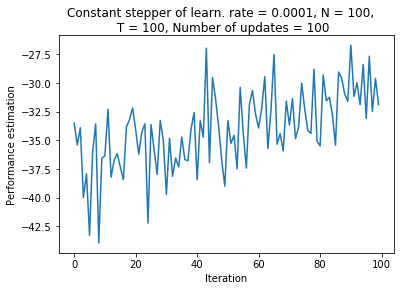

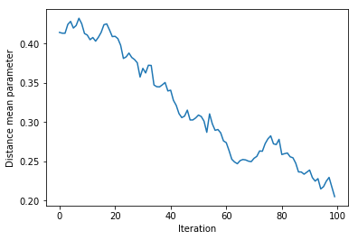

```python
learning_rate = 0.0001
stepper = ConstantStep(learning_rate)
mean_parameters = []
avg_return = []
distance_return = []
theta = theta0
mean_parameters.append(theta)
for _ in range(n_itr):
    policy = Gaussian_policy(0.5,theta)
    paths = utils.collect_episodes(env, policy=policy, horizon=T, n_episodes=N)
    mean_estimation = REINFORCE(paths,discount)
    theta = update_parameters(mean_estimation,theta,stepper)
    performance = average_perfomance(paths,discount)
    distance = distance_to_optimal(theta)
    mean_parameters.append(theta)
    avg_return.append(performance)
    distance_return.append(distance)

# plot the average return obtained by simulating the policy
# at each iteration of the algorithm (this is a rought estimate
# of the performance
plt.figure()
plt.plot(avg_return)
plt.suptitle('Constant stepper of learn. rate = '+str(learning_rate)+ ', N = ' +str(N)+',\n T = '+str(T)+", Number \
of updates = " + str(n_itr))
plt.xlabel('Iteration')
plt.ylabel('Performance estimation')
plt.show()

# plot the distance mean parameter
# of iteration k
plt.figure()
plt.plot(distance_return)
plt.xlabel('Iteration')
plt.ylabel('Distance mean parameter')
plt.show()
```

```python
np.argmin(distance_return)
```

```
99
```

```python
distance_return[99]
```

```
array([ 0.20504785])
```

We can notice that when using a constant learning rate, tuning is very important. In fact, the convergence depend on how far is the initial value of the parameter from the optimal one, and the value of the learning rate. This learning rate is the parameter which determines how fast or slow we will move towards the optimal parameters. If it's very large we will skip the optimal solution and then diverge as we can see in the first two experiments using 0.1 and 0.01 as learning rates. If it is too small we will need too many iterations to converge to the best values as we can see in the fourth experiment using a learning rate of 0.0001 after 100 iterations we still far from the optimal value by a distance of 0.20 which is considered large. So using a good learning rate is crucial. Here 0.001 seems to work well since it converges rapidly (95 iterations) and more precisely (a distance of 0.007). We can control the number of updating by thresholding the distance to the optimal value which will be more precise and avoid to skip the optimal value. Next we will use a harmonical steeper and see what it gives.

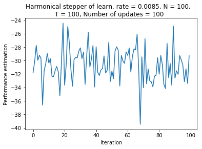

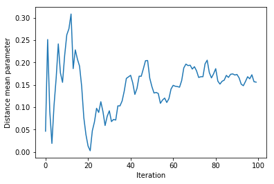

```python
learning_rate = 0.0085
stepper = HarmonicStep(learning_rate)
mean_parameters = []
avg_return = []
distance_return = []
theta = theta0
mean_parameters.append(theta)
for _ in range(n_itr):
    policy = Gaussian_policy(0.5,theta)
    paths = utils.collect_episodes(env, policy=policy, horizon=T, n_episodes=N)
    mean_estimation = REINFORCE(paths,discount)
    theta = theta + stepper.update(_+1,mean_estimation)
    performance = average_perfomance(paths,discount)
    distance = distance_to_optimal(theta)
    mean_parameters.append(theta)
    avg_return.append(performance)
    distance_return.append(distance)

# plot the average return obtained by simulating the policy
# at each iteration of the algorithm (this is a rought estimate
# of the performance
plt.figure()
plt.plot(avg_return)
plt.suptitle('Harmonical stepper of learn. rate = '+str(learning_rate)+ ', N = ' +str(N)+',\n T = '+str(T)+", Number \
of updates = " + str(n_itr))
plt.xlabel('Iteration')
plt.ylabel('Performance estimation')
plt.show()

# plot the distance mean parameter
# of iteration k
plt.figure()
plt.plot(distance_return)
plt.xlabel('Iteration')
plt.ylabel('Distance mean parameter')
plt.show()
```

```python
np.argmin(distance_return)
```

```
21
```

```python
print(distance_return[21])
```

```
[ 0.00296752]
```

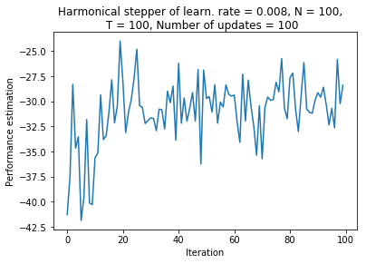

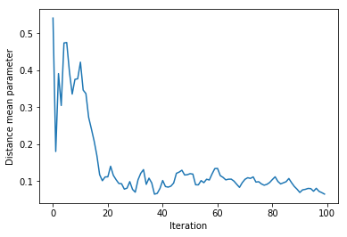

```python
learning_rate = 0.008
stepper = HarmonicStep(learning_rate)
mean_parameters = []
avg_return = []
distance_return = []
theta = theta0
mean_parameters.append(theta)
for _ in range(n_itr):
    policy = Gaussian_policy(0.5,theta)
    paths = utils.collect_episodes(env, policy=policy, horizon=T, n_episodes=N)
    mean_estimation = REINFORCE(paths,discount)
    theta = theta + stepper.update(_+1,mean_estimation)
    performance = average_perfomance(paths,discount)
    distance = distance_to_optimal(theta)
    mean_parameters.append(theta)
    avg_return.append(performance)
    distance_return.append(distance)

# plot the average return obtained by simulating the policy
# at each iteration of the algorithm (this is a rought estimate
# of the performance
plt.figure()
plt.plot(avg_return)
plt.suptitle('Harmonical stepper of learn. rate = '+str(learning_rate)+ ', N = ' +str(N)+',\n T = '+str(T)+", Number \
of updates = " + str(n_itr))
plt.xlabel('Iteration')
plt.ylabel('Performance estimation')
plt.show()

# plot the distance mean parameter
# of iteration k
plt.figure()
plt.plot(distance_return)
plt.xlabel('Iteration')
plt.ylabel('Distance mean parameter')
plt.show()
```

```python
np.argmin(distance_return)
```

```
37
```

```python
print(distance_return[37])
```

```
[ 0.06482542]
```

We can notice that when using an harmonical steeper, the convergence is smoother as the number of iterations increases, the fact that we couldn't see when using a constant step. When using a learning rate of 0.0085, the convergence is fast but a little bit large because we skip it after the 21 iteration, this is duo also to the fact that we don't controle the number of updates by the value to the distance to the minimal value (which has reached a minimum of 0.0029 here). From another side when decreasing the learning rate to 0.008, we could see that the convergence is slow since the curve of Distance to the optimal value seems to still decreasing with the number of iterations, but we have reached a minimal value of distance of 0.06 at the 38 iterations which is not bad. We could test other values in the interval [0.008,0.0085] which will give a better control to the trade-off between fast convergence and more precise optimal value. Next we will test the Adam algorithm and compare it with the previous experiments.

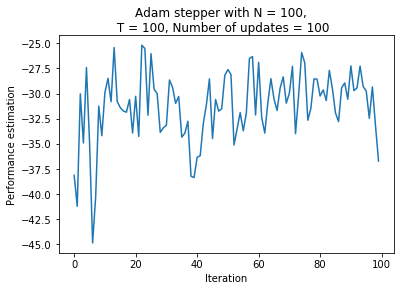

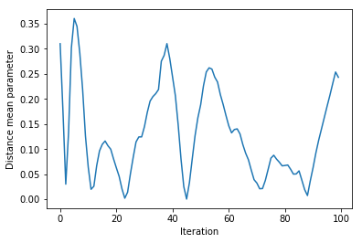

```python
class AdamStep(object):
    def __init__(self, b1, b2, eps, alpha):
        self.b1 = b1
        self.b2 = b2
        self.eps = eps
        self.alpha = alpha
    def update(self, gt, m, v):
        mt = self.b1*m[-1]+(1-self.b1)*gt
        vt = self.b2*v[-1]+(1-self.b2)*gt**2
        m.append(mt)
        v.append(vt)
        mt = mt/(1-self.b1)
        vt = vt/(1-self.b2)
        return (self.alpha*mt)/((sqrt(vt)+self.eps))

m = [0]
v = [0]
stepper = AdamStep(b1=0.9,b2=0.999,eps=10**-8,alpha=0.1)
mean_parameters = []
avg_return = []
distance_return = []
theta = theta0
mean_parameters.append(theta)
for _ in range(n_itr):
    policy = Gaussian_policy(0.5,theta)
    paths = utils.collect_episodes(env, policy=policy, horizon=T, n_episodes=N)
    mean_estimation = REINFORCE(paths,discount)
    theta = theta + stepper.update(mean_estimation, m,v)
    performance = average_perfomance(paths,discount)
    distance = distance_to_optimal(theta)
    mean_parameters.append(theta)
    avg_return.append(performance)
    distance_return.append(distance)

# plot the average return obtained by simulating the policy
# at each iteration of the algorithm (this is a rought estimate
# of the performance
plt.figure()
plt.plot(avg_return)
plt.suptitle('Adam stepper with N = ' +str(N)+',\n T = '+str(T)+", Number \
of updates = " + str(n_itr))
plt.xlabel('Iteration')
plt.ylabel('Performance estimation')
plt.show()

# plot the distance mean parameter
# of iteration k
plt.figure()
plt.plot(distance_return)
plt.xlabel('Iteration')
plt.ylabel('Distance mean parameter')
plt.show()
```

```python
np.argmin(distance_return)
```

```
45
```

```python
print(distance_return[45])
```

[output not shown]

```python
avg_return[45]
```

```
-34.471161006390204
```

We could see that the Adam stepper gives the best approximation of the optimal value (a $10^{-3}$ precision) and it converges rapidly at the $45^{th}$ iteration, and after that it roll away from the optimal value but it return to it after some iterations (doesn't diverge) since we could see some picks below the y=0 axis. So this method is better than the other ones which need to tune the value of the learning rate to get a good trade-off between rapid convergence and good precision. Next we will see how the performance changes with respect to the horizon parameter T.

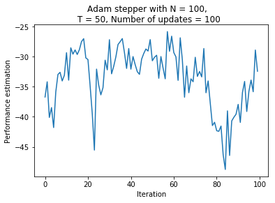

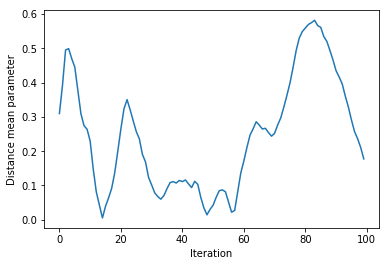

```python
T = 50
m = [0]
v = [0]
stepper = AdamStep(b1=0.9,b2=0.999,eps=10**-8,alpha=0.1)
mean_parameters = []
avg_return = []
distance_return = []
theta = theta0
mean_parameters.append(theta)
for _ in range(n_itr):
    policy = Gaussian_policy(0.5,theta)
    paths = utils.collect_episodes(env, policy=policy, horizon=T, n_episodes=N)
    mean_estimation = REINFORCE(paths,discount)
    theta = theta + stepper.update(mean_estimation, m,v)
    performance = average_perfomance(paths,discount)
    distance = distance_to_optimal(theta)
    mean_parameters.append(theta)
    avg_return.append(performance)
    distance_return.append(distance)

# plot the average return obtained by simulating the policy
# at each iteration of the algorithm (this is a rought estimate
# of the performance
plt.figure()
plt.plot(avg_return)
plt.suptitle('Adam stepper with N = ' +str(N)+',\n T = '+str(T)+", Number \
of updates = " + str(n_itr))
plt.xlabel('Iteration')
plt.ylabel('Performance estimation')
plt.show()

# plot the distance mean parameter
# of iteration k
plt.figure()
plt.plot(distance_return)
plt.xlabel('Iteration')
plt.ylabel('Distance mean parameter')
plt.show()
```

```python
np.argmin(distance_return)
```

```
14
```

```python
print(distance_return[14])
```

```
[ 0.0052981]
```

```python
avg_return[14]
```

```
-28.899740910613197
```

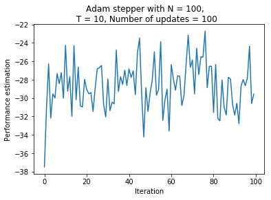

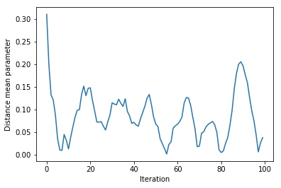

```python
T = 10
m = [0]
v = [0]
stepper = AdamStep(b1=0.9,b2=0.999,eps=10**-8,alpha=0.1)
mean_parameters = []
avg_return = []
distance_return = []
theta = theta0
mean_parameters.append(theta)
for _ in range(n_itr):
    policy = Gaussian_policy(0.5,theta)
    paths = utils.collect_episodes(env, policy=policy, horizon=T, n_episodes=N)
    mean_estimation = REINFORCE(paths,discount)
    theta = theta + stepper.update(mean_estimation, m,v)
    performance = average_perfomance(paths,discount)
    distance = distance_to_optimal(theta)
    mean_parameters.append(theta)
    avg_return.append(performance)
    distance_return.append(distance)

# plot the average return obtained by simulating the policy
# at each iteration of the algorithm (this is a rought estimate
# of the performance
plt.figure()
plt.plot(avg_return)
plt.suptitle('Adam stepper with N = ' +str(N)+',\n T = '+str(T)+", Number \
of updates = " + str(n_itr))
plt.xlabel('Iteration')
plt.ylabel('Performance estimation')
plt.show()

# plot the distance mean parameter
# of iteration k
plt.figure()
plt.plot(distance_return)
plt.xlabel('Iteration')
plt.ylabel('Distance mean parameter')
plt.show()
```

```python
np.argmin(distance_return)
```

```
55
```

```python
print(distance_return[55])
```

```
[ 0.00190642]
```

```python
avg_return[55]
```

```
-23.862450569647937
```

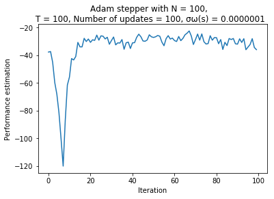

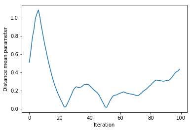

```python
T = 100
m = [0]
v = [0]
stepper = AdamStep(b1=0.9,b2=0.999,eps=10**-8,alpha=0.1)
mean_parameters = []
avg_return = []
distance_return = []
theta = theta0
mean_parameters.append(theta)
for _ in range(n_itr):
    policy = Gaussian_policy(0.0000001,theta)
    paths = utils.collect_episodes(env, policy=policy, horizon=T, n_episodes=N)
    mean_estimation = REINFORCE(paths,discount)
    theta = theta + stepper.update(mean_estimation, m,v)
    performance = average_perfomance(paths,discount)
    distance = distance_to_optimal(theta)
    mean_parameters.append(theta)
    avg_return.append(performance)
    distance_return.append(distance)

# plot the average return obtained by simulating the policy
# at each iteration of the algorithm (this is a rought estimate
# of the performance
plt.figure()
plt.plot(avg_return)
plt.suptitle('Adam stepper with N = ' +str(N)+',\n T = '+str(T)+", Number \
of updates = " + str(n_itr)+", σω(s) = 0.0000001")
plt.xlabel('Iteration')
plt.ylabel('Performance estimation')
plt.show()

# plot the distance mean parameter
# of iteration k
plt.figure()
plt.plot(distance_return)
plt.xlabel('Iteration')
plt.ylabel('Distance mean parameter')
plt.show()
```

```python
np.argmin(distance_return)
```

```
51
```

```python
np.min(distance_return)
```

```
0.014820000793573151
```

```python
avg_return[51]
```

```
-26.632938742703818
```

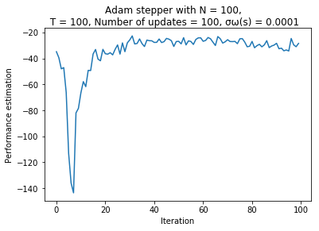

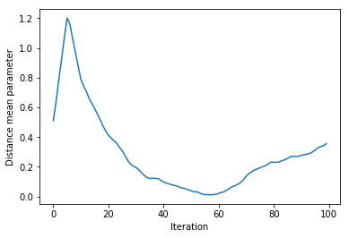

```python
T = 100
m = [0]
v = [0]
stepper = AdamStep(b1=0.9,b2=0.999,eps=10**-8,alpha=0.1)
mean_parameters = []
avg_return = []
distance_return = []
theta = theta0
mean_parameters.append(theta)
for _ in range(n_itr):
    policy = Gaussian_policy(0.0001,theta)
    paths = utils.collect_episodes(env, policy=policy, horizon=T, n_episodes=N)
    mean_estimation = REINFORCE(paths,discount)
    theta = theta + stepper.update(mean_estimation, m,v)
    performance = average_perfomance(paths,discount)
    distance = distance_to_optimal(theta)
    mean_parameters.append(theta)
    avg_return.append(performance)
    distance_return.append(distance)

# plot the average return obtained by simulating the policy
# at each iteration of the algorithm (this is a rought estimate
# of the performance
plt.figure()
plt.plot(avg_return)
plt.suptitle('Adam stepper with N = ' +str(N)+',\n T = '+str(T)+", Number \
of updates = " + str(n_itr)+", σω(s) = 0.0001")
plt.xlabel('Iteration')
plt.ylabel('Performance estimation')
plt.show()

# plot the distance mean parameter
# of iteration k
plt.figure()
plt.plot(distance_return)
plt.xlabel('Iteration')
plt.ylabel('Distance mean parameter')
plt.show()
```

```python
np.argmin(distance_return)
```

```
57
```

```python
print(distance_return[57])
```

```
[ 0.01018833]
```

```python
print(avg_return[57])
```

```
-25.4221350121
```

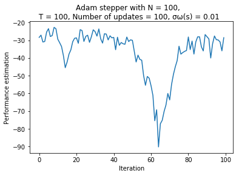

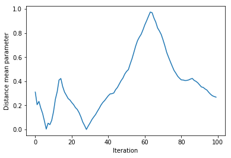

```python
T = 100
m = [0]
v = [0]
stepper = AdamStep(b1=0.9,b2=0.999,eps=10**-8,alpha=0.1)
mean_parameters = []
avg_return = []
distance_return = []
theta = theta0
mean_parameters.append(theta)
for _ in range(n_itr):
    policy = Gaussian_policy(0.01,theta)
    paths = utils.collect_episodes(env, policy=policy, horizon=T, n_episodes=N)
    mean_estimation = REINFORCE(paths,discount)
    theta = theta + stepper.update(mean_estimation, m,v)
    performance = average_perfomance(paths,discount)
    distance = distance_to_optimal(theta)
    mean_parameters.append(theta)
    avg_return.append(performance)
    distance_return.append(distance)

# plot the average return obtained by simulating the policy
# at each iteration of the algorithm (this is a rought estimate
# of the performance
plt.figure()
plt.plot(avg_return)
plt.suptitle('Adam stepper with N = ' +str(N)+',\n T = '+str(T)+", Number \
of updates = " + str(n_itr)+", σω(s) = 0.01")
plt.xlabel('Iteration')
plt.ylabel('Performance estimation')
plt.show()

# plot the distance mean parameter
# of iteration k
plt.figure()
plt.plot(distance_return)
plt.xlabel('Iteration')
plt.ylabel('Distance mean parameter')
plt.show()
```

```python
np.argmin(distance_return)
```

```
28
```

```python
print(distance_return[28])
```

```
[ 0.00037807]
```

```python
print(avg_return[28])
```

```
-28.0038724991
```

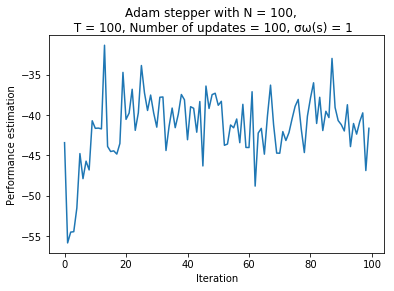

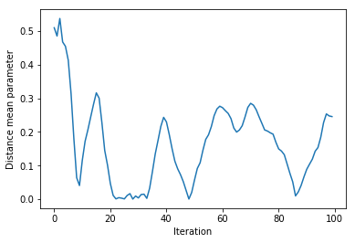

```python
T = 100
m = [0]
v = [0]
stepper = AdamStep(b1=0.9,b2=0.999,eps=10**-8,alpha=0.1)
mean_parameters = []
avg_return = []
distance_return = []
theta = theta0
mean_parameters.append(theta)
for _ in range(n_itr):
    policy = Gaussian_policy(1,theta)
    paths = utils.collect_episodes(env, policy=policy, horizon=T, n_episodes=N)
    mean_estimation = REINFORCE(paths,discount)
    theta = theta + stepper.update(mean_estimation, m,v)
    performance = average_perfomance(paths,discount)
    distance = distance_to_optimal(theta)
    mean_parameters.append(theta)
    avg_return.append(performance)
    distance_return.append(distance)

# plot the average return obtained by simulating the policy
# at each iteration of the algorithm (this is a rought estimate
# of the performance
plt.figure()
plt.plot(avg_return)
plt.suptitle('Adam stepper with N = ' +str(N)+',\n T = '+str(T)+", Number \
of updates = " + str(n_itr)+", σω(s) = 1")
plt.xlabel('Iteration')
plt.ylabel('Performance estimation')
plt.show()

# plot the distance mean parameter
# of iteration k
plt.figure()
plt.plot(distance_return)
plt.xlabel('Iteration')
plt.ylabel('Distance mean parameter')
plt.show()
```

```python
np.argmin(distance_return)
```

```
28
```

```python
print(distance_return[28])
```

```
[ 0.00039179]
```

```python
print(avg_return[28])
```

```
-37.5251219662
```

We could see that the convergence becomes smooth as we decrease the standard deviation, and the oscillations become more severe as we increases it. For the convergence to the optimal value, it's more precise when we increase the variance because we are increasing the space of the possible actions and then we are allowing for more exploration.